# Expedia Code - Marco Hassan - January 2019

```r
remove(data2)
```

=========== More exotic options with low aggregated USD value seem to be prefered by mobiles in comparison to high aggregated values where Desktop domins ===========

```
Ignoring unknown parameters: binwidth, bins, pad
```

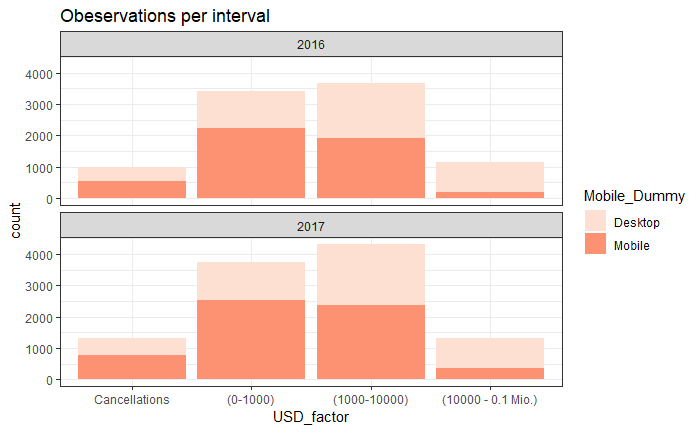

```r
data$USD_factor <- cut(data$Net_USD, c(-10^10, 0, 1000, 10000, 100000, 10^6, 10^20))
levels(data$USD_factor) <- c("Cancellations", "(0-1000)", "(1000-10000)", "(10000 - 0.1 Mio.)", "(0.1-1 Mio.)", ">1 Mio.")
data2 <- sqldf("SELECT * FROM data
             WHERE Region IN ('NOAM')
             AND USD_factor NOT IN ('(0.1-1 Mio.)', '>1 Mio.')")
ggplot(data2,
      aes(x = USD_factor)) +
      geom_histogram(aes(fill = Mobile_Dummy), stat="count") +
      scale_fill_brewer(palette = "Reds")+ ggtitle("Obeservations per interval")+
      facet_wrap(~year, nrow=2)+ theme(axis.text.x=element_blank(),
                                   axis.ticks.x=element_blank())+
      theme_bw()
```

```
Ignoring unknown parameters: binwidth, bins, pad
```

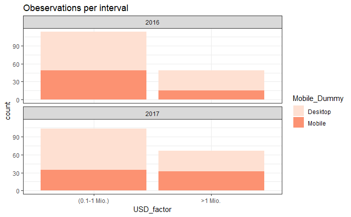

```r
remove(data2)
data2 <- sqldf("SELECT * FROM data
             WHERE Region IN ('NOAM')
             AND USD_factor IN ('(0.1-1 Mio.)', '>1 Mio.')")
ggplot(data2,
      aes(x = USD_factor)) +
      geom_histogram(aes(fill = Mobile_Dummy), stat="count") +
      scale_fill_brewer(palette = "Reds")+ ggtitle("Obeservations per interval")+
      facet_wrap(~year, nrow=2)+ theme(axis.text.x=element_blank(),
                                   axis.ticks.x=element_blank())+
      theme_bw()
```

```r
remove(data2)
```

=== Times Series Trend ===

For 2016 - check for seasonality

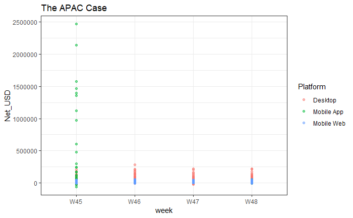

```r
data_16 <- sqldf("SELECT *
                  FROM data WHERE year = '2016'
                  AND Origin NOT IN ('US')")
data_17 <- sqldf("SELECT *
                  FROM data WHERE year = '2017'
                  AND Origin NOT IN ('US')")
ggplot(data_16%>% filter(Region == "APAC"), aes(x = week, y= Net_USD)) + geom_point(aes(color = Platform),alpha = 0.5) + ggtitle("The APAC Case") + theme_bw()
```

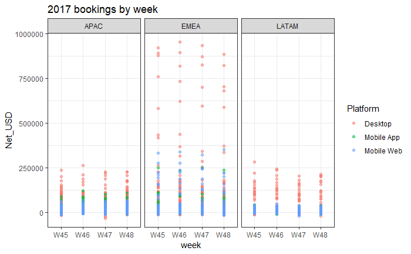

```r
ggplot(data_17, aes(x = week, y= Net_USD)) + geom_point(aes(color = Platform), alpha = 0.5) + facet_wrap(~Region) + ggtitle("2017 bookings by week")+ theme_bw()
```

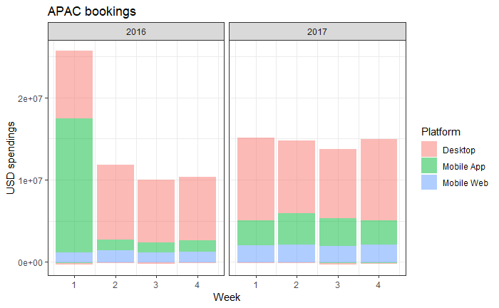

```r
## Something clearly happened in 2016 with exposive mobile app booking in week 45.
## Plot just the two for the presentation
ggplot(sqldf("SELECT * FROM data WHERE Region IN ('APAC')"), aes(x = as.numeric(week), y= Net_USD)) + geom_bar(stat = "identity",aes(fill = Platform), alpha = 0.5) + facet_wrap(~year) + xlab("Week") + ylab("USD spendings") + ggtitle("APAC bookings")+ theme_bw()
```

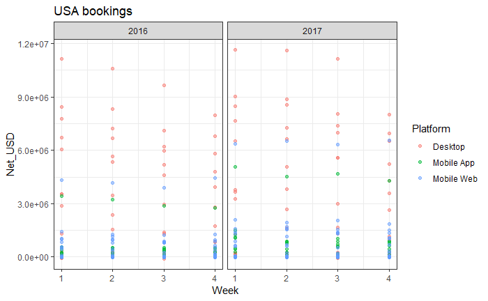

```r
## Plots for USA
ggplot(sqldf("SELECT * FROM data WHERE Origin IN ('US')"), aes(x = as.numeric(week), y= Net_USD)) + geom_point(aes(color = Platform), alpha = 0.5) + facet_wrap(~year)+ ggtitle("USA bookings") + xlab("Week") + theme_bw()
```

```r
## Also for other countries there is the net distinction Desktop vs. Mobile for different transaction types.
remove(data_16)
remove(data_17)
```

APAC Analysis

```r
sqldf("SELECT * FROM data
      WHERE year = '2016'
      AND Net_USD > 500000
      AND Region = 'APAC'
      AND Platform = 'Mobile App'
      ORDER BY Net_USD DESC") ## --> Promotion from australia to australia for big companies/luxury stayings for all of the windows. Boom especilly for short term options.
```

```
  year week Mobile_Dummy   Platform Region    Origin     Window Destination   Net_USD
1 2016  W45       Mobile Mobile App   APAC Australia   0-1 days   Australia 2469900.1
2 2016  W45       Mobile Mobile App   APAC Australia   2-3 days   Australia 2142800.2
3 2016  W45       Mobile Mobile App   APAC Australia 15-30 days   Australia 1578100.2
4 2016  W45       Mobile Mobile App   APAC Australia   4-7 days   Australia 1466000.4
5 2016  W45       Mobile Mobile App   APAC Australia 31-45 days   Australia 1396200.5
6 2016  W45       Mobile Mobile App   APAC Australia  8-14 days   Australia 1354300.9
7 2016  W45       Mobile Mobile App   APAC Australia 61-90 days   Australia 1120300.7
8 2016  W45       Mobile Mobile App   APAC Australia 46-60 days   Australia  972100.4
9 2016  W45       Mobile Mobile App   APAC Australia   +90 days   Australia  603400.8
  Net_Order   USD_factor
1       121      >1 Mio.
2        90      >1 Mio.
3        52      >1 Mio.
4        70      >1 Mio.
5        37      >1 Mio.
6        49      >1 Mio.
7        21      >1 Mio.
8        23 (0.1-1 Mio.)
9        14 (0.1-1 Mio.)
```

============ Windows lags ============

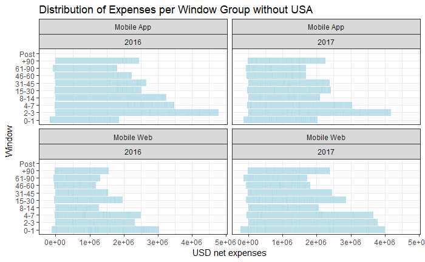

```r
a <- data %>% filter(Platform != "Desktop", Region != "NOAM")
levels(a$Window) <- c("0-1", "2-3", "4-7", "8-14", "15-30", "31-45", "46-60", "61-90", "+90", "Post")
ggplot(a, aes(x = Window, y = Net_USD)) + geom_bar(stat = "identity", fill = "lightblue", alpha = 0.8) + facet_wrap(~Platform+year)+ coord_flip()+ ylab("USD net expenses") +
ggtitle("Distribution of Expenses per Window Group without USA")+ theme_bw()
```

```r
remove(a)
# Count number of window in different weeks
#sqldf("SELECT Window, week, COUNT(Window) FROM data WHERE Mobile_Dummy = 'Mobile' GROUP BY #Window, week") ## confirmed.
```

Check Cancellation by break

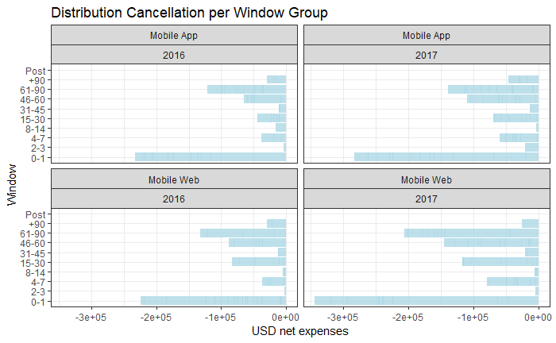

```r
data2 <- data %>% filter(Platform != "Desktop")
levels(data2$Window) <- c("0-1", "2-3", "4-7", "8-14", "15-30", "31-45", "46-60", "61-90", "+90", "Post")
ggplot(data2 %>% filter(Net_USD < 0), aes(x = Window, y = Net_USD)) +
  geom_bar(stat = "identity", fill = "lightblue",alpha = 0.8) +
  facet_wrap(~Platform+year)+ coord_flip()+ ylab("USD net expenses") +
  ggtitle("Distribution Cancellation per Window Group")+ theme_bw()
```

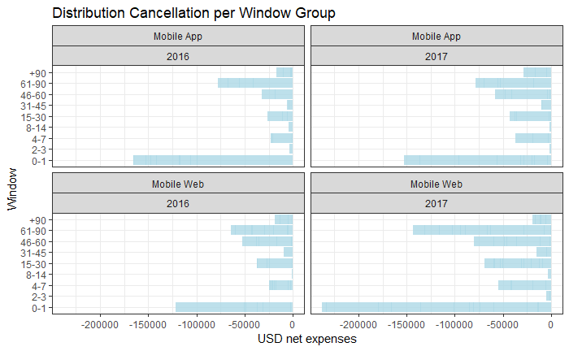

```r
ggplot(data2 %>% filter(Net_USD < 0, Region != "NOAM"), aes(x = Window, y = Net_USD)) +
  geom_bar(stat = "identity", fill = "lightblue",alpha = 0.8) +
  facet_wrap(~Platform+year) + coord_flip()+ ylab("USD net expenses") +
  ggtitle("Distribution Cancellation per Window Group")+ theme_bw()
```

```r
remove(data2)
```

===================== Check New year effect =====================

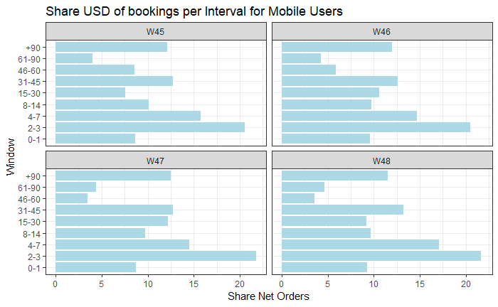

```r
data2 <- sqldf("SELECT week,Mobile_Dummy, Window, SUM(Net_USD) as Num_USD FROM data
               GROUP BY week, Window")
data2 <- left_join(data2, sqldf("SELECT week, SUM(Net_USD) as Total_USD FROM data GROUP BY week"), by = "week") ## to save time used dplyr.
data2 <-cbind(data2,
      Share_USD = round((data2$Num_USD/data2$Total_USD)*100,2)) %>%
      select(-c(Num_USD, Total_USD))
levels(data2$Window) <- c("0-1", "2-3", "4-7", "8-14", "15-30", "31-45", "46-60", "61-90", "+90", "Post")
ggplot(data2 %>% filter(Window != "Post", Mobile_Dummy == "Mobile"),
       aes(x=Window, y=Share_USD)) +
       geom_linerange(aes(ymin = 0, ymax = Share_USD), color = "lightblue",
                      size = 5) + facet_wrap(~week) +
       ylab("Share Net Orders") + coord_flip() +
       ggtitle("Share USD of bookings per Interval for Mobile Users") + theme_bw()
```

```r
## No december effect. Biggest is always 2-3 days and not too many bookings for end december period.
## color by share?
remove(data2)
```

==== Map distribution ====

Use map_data to get a world map where to plot

```r
map_world <- map_data('world')
## Check by anti join if there are unmatched countries in the two datasets
#sqldf("SELECT Destination
      #FROM destination_expense
      #WHERE Destination NOT IN (SELECT region FROM map_world)")
## Check how big average expenses in such countries
#sqldf("SELECT Destination, AvgUSD
#      FROM destination_expense
#      WHERE Destination NOT IN (SELECT region FROM map_world)
#     ORDER BY AvgUSD DESC")
## Rename obvious and largest ones. Drop the others for convenience here.
data <- sqldf(c("UPDATE data
      SET Destination = CASE
                            WHEN Destination = 'United States of America'  THEN   'USA'
                            WHEN Destination = 'United Kingdom'            THEN   'UK'
                            WHEN Destination = 'Spain & Canary Islands'    THEN   'Spain'
                            WHEN Destination = 'Taiwan, Republic of China' THEN   'Taiwan'
                        END
      WHERE Destination IN ('United Kingdom', 'Spain & Canary Islands',
                            'United States of America', 'Taiwan, Republic of China')",
      "SELECT * FROM main.data"))
```

```
Don't need to call dbFetch() for statements, only for queries
```

Get Coordinates of the countries to plot.

```r
## Extract Coordinates by Country
wmap <- getMap(resolution="high")
```

```
for resolution='high' option you need to install package rworldxtra, using low resolution version for now
```

```r
# get centroids
centroids <- gCentroid(wmap, byid=TRUE)

# get a data.frame with centroids
df <- as.data.frame(centroids)
df <- cbind(rownames(df), df); colnames(df)[1] <- "Country"
## Check by anti join if there are unmatched countries in the two datasets
#sqldf("SELECT Destination FROM destination_expense
      #WHERE Destination NOT IN (SELECT Country FROM df)") ## no coordinates for those
## Get Coordinates
data$Longitude <- NA
data$Latitude <- NA
data$Longitude <- df[data$Destination, 2]
data$Latitude <- df[data$Destination, 3]
```

Create aggregate statistics by Destination Country

```r
destination_expense <- sqldf("SELECT Destination, SUM(Net_Order) as SumOrder,
                             avg(Net_USD) as AvgUSD
                             FROM data
                             WHERE Region == 'NOAM'
                             AND Mobile_Dummy = 'Mobile'
                             AND Window == '2-3 days'
                             GROUP BY Destination")
```

Join Datasets

```r
destination_expense <- sqldf("SELECT *
                             FROM map_world
                             LEFT JOIN destination_expense
                             ON map_world.region = destination_expense.Destination")
```

Plot using logarithm as otherwise all the color scale dominated by USA

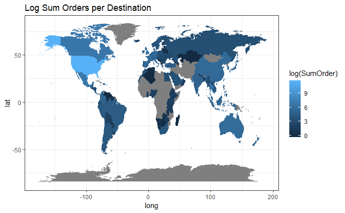

```r
ggplot(destination_expense, aes(x = long, y = lat, group = group)) +
  ggtitle("Log Sum Orders per Destination")+
  geom_polygon(aes(fill = log(SumOrder))) + theme_bw()
```

Plot just for high share

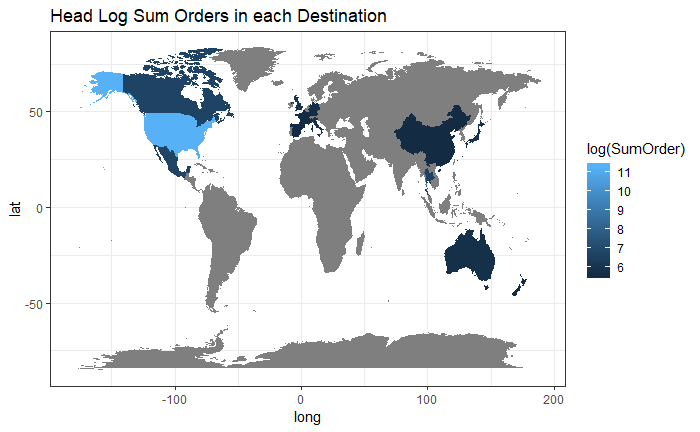

```r
#destination_expense <- sqldf(c("UPDATE destination_expense
#                                SET AvgUSD = 'NA'
#                                WHERE LOG(AvgUSD) < 8",
#                                "SELECT * FROM main.destination_expense")) --> sqldf does not support log
destination_expense <- data %>% filter(Mobile_Dummy == "Mobile",
                                       Region == "NOAM", Mobile_Dummy == 'Mobile',
                                       Window == "2-3 days")      %>%
                                group_by(Destination)             %>%
                                mutate(Median_USD = median(Net_USD),
                                       AvgUSD = mean(Net_USD),
                                       SumOrder = sum(Net_Order)) %>%
                                filter(log(SumOrder)>5.5)         %>%
                                select(-Net_USD)
destination_expense <- sqldf("SELECT *
                             FROM destination_expense
                             GROUP BY Destination")
destination_expense <- sqldf("SELECT *
                             FROM map_world
                             LEFT JOIN destination_expense
                             ON map_world.region = destination_expense.Destination")
ggplot(destination_expense, aes(x = long, y = lat, group = group)) +
  ggtitle("Head Log Sum Orders in each Destination")+
  geom_polygon(aes(fill = log(SumOrder))) + theme_bw()
```

=== Others ===

In this section I’ll try with the same procedure as before to check if small investments are rather addressed to exotic countries.

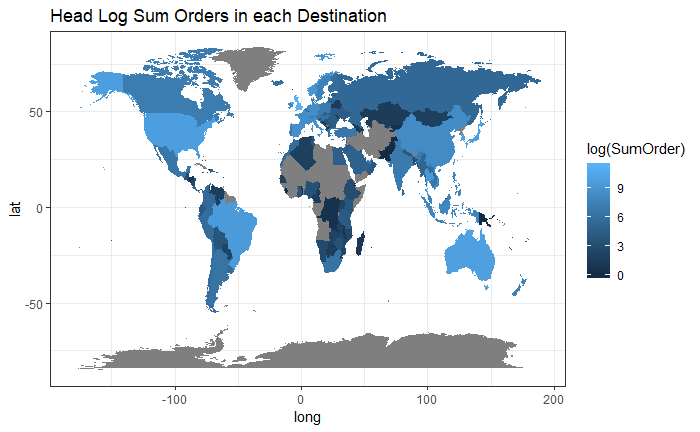

```r
## Use dplyr data wrangling to add both median and average to save time.
destination_expense <- data %>% filter(Mobile_Dummy == "Mobile", Region != "NOAM") %>%
                                group_by(Destination)                              %>%
                                mutate(Median_USD = median(Net_USD),
                                       AvgUSD = mean(Net_USD),
                                       SumOrder = sum(Net_Order))                  %>%
                                select(-Net_USD)
destination_expense <- sqldf("SELECT * FROM destination_expense GROUP BY Destination")
destination_expense <- sqldf("SELECT *
                             FROM map_world
                             LEFT JOIN destination_expense
                             ON map_world.region = destination_expense.Destination")
## Checking at Orders
ggplot(destination_expense, aes(x = long, y = lat, group = group)) +
  ggtitle("Head Log Sum Orders in each Destination")+
  geom_polygon(aes(fill = log(SumOrder))) + theme_bw()
```

Logarithm higher than 6

```r
destination_expense <- data %>% filter(Mobile_Dummy == "Mobile",
                                       Region != "NOAM",
                                       Mobile_Dummy == 'Mobile')     %>%
                                group_by(Destination)                %>%
                                mutate(Median_USD = median(Net_USD),
                                       AvgUSD = mean(Net_USD),
                                       SumOrder = sum(Net_Order))    %>%
                                filter(log(SumOrder)>6)              %>%
                                select(-Net_USD)
```

```
NaNs producedNaNs produced
```

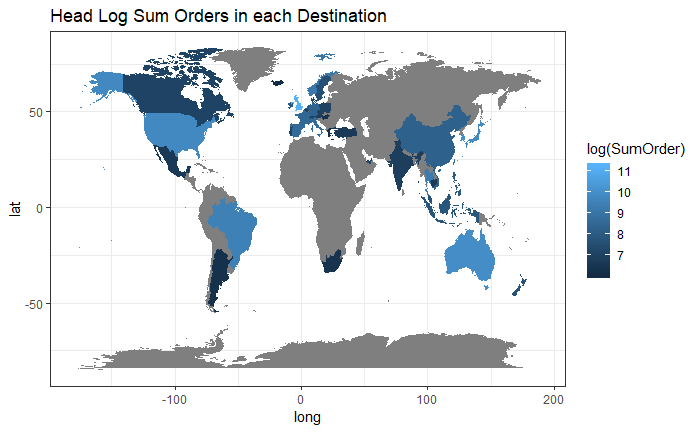

```r
destination_expense <- sqldf("SELECT * FROM destination_expense GROUP BY Destination")
destination_expense <- sqldf("SELECT *
                             FROM map_world
                             LEFT JOIN destination_expense
                             ON map_world.region = destination_expense.Destination")
ggplot(destination_expense, aes(x = long, y = lat, group = group)) +
  ggtitle("Head Log Sum Orders in each Destination")+
  geom_polygon(aes(fill = log(SumOrder))) + theme_bw()
```